# Multivariate Analysis Mini-Project: Customer Segmentation

Data Science Team

2026-05-25

# 1. Introduction

This report presents a comprehensive multivariate analysis of the **Wholesale Customers Dataset** from the UCI Machine Learning Repository. The primary objective is to segment customers into distinct, actionable profiles based on their annual spending across various product categories.

We will employ **Principal Component Analysis (PCA)** for dimensionality reduction and variable relationship mapping, followed by **K-Means Clustering** to identify the customer segments.

# 2. Data Acquisition & Setup

We begin by loading the necessary libraries and fetching the dataset directly from its source.

```r
# Load required libraries
library(tidyverse)
library(FactoMineR)
library(factoextra)
library(cluster)
library(corrplot)
```

```r
url <- "https://archive.ics.uci.edu/ml/machine-learning-databases/00292/Wholesale%20customers%20data.csv"
data <- read.csv(url)

# Factorize categorical variables
data$Channel <- factor(data$Channel, levels = c(1, 2), labels = c("Horeca", "Retail"))
data$Region <- factor(data$Region, levels = c(1, 2, 3), labels = c("Lisbon", "Oporto", "Other"))

str(data)
```

```
## 'data.frame':    440 obs. of  8 variables:
##  $ Channel         : Factor w/ 2 levels "Horeca","Retail": 2 2 2 1 2 2 2 2 1 2 ...
##  $ Region          : Factor w/ 3 levels "Lisbon","Oporto",..: 3 3 3 3 3 3 3 3 3 3 ...
##  $ Fresh           : int  12669 7057 6353 13265 22615 9413 12126 7579 5963 6006 ...
##  $ Milk            : int  9656 9810 8808 1196 5410 8259 3199 4956 3648 11093 ...
##  $ Grocery         : int  7561 9568 7684 4221 7198 5126 6975 9426 6192 18881 ...
##  $ Frozen          : int  214 1762 2405 6404 3915 666 480 1669 425 1159 ...
##  $ Detergents_Paper: int  2674 3293 3516 507 1777 1795 3140 3321 1716 7425 ...
##  $ Delicassen      : int  1338 1776 7844 1788 5185 1451 545 2566 750 2098 ...
```

The dataset contains 440 observations and 8 variables. This meets the minimum requirement of $\ge$ 200 rows and $\ge$ 8 variables. The 6 continuous variables representing annual spending (Fresh, Milk, Grocery, Frozen, Detergents_Paper, Delicassen) will be the focus of our PCA and clustering.

# 3. Data Preparation

Data preprocessing is a critical step. Wholesale spending data is generally strictly positive and heavily right-skewed (some customers buy significantly more than the median).

```r
# Check for missing values
sum(is.na(data))
```

```
## [1] 0
```

```r
# Extract numeric features
data_numeric <- data %>% select(-Channel, -Region)

# Apply log(x+1) transformation to handle right skewness
data_log <- log1p(data_numeric)

# Standardize data (mean = 0, sd = 1)
data_scaled <- as.data.frame(scale(data_log))
```

**Justification for preprocessing:** 1. **Missing values:** None detected. If present, we would impute using median or drop rows if minimal. 2. **Log Transformation:** Normalizes the distribution of skewed financial data, making PCA more robust. 3. **Scaling:** Essential for both PCA and K-Means, as these algorithms are distance-based. Scaling ensures features with larger magnitudes (e.g., Fresh) don’t disproportionately dominate the analysis.

# 4. Exploratory Data Analysis (EDA)

Before running advanced algorithms, we explore linear relationships between the variables.

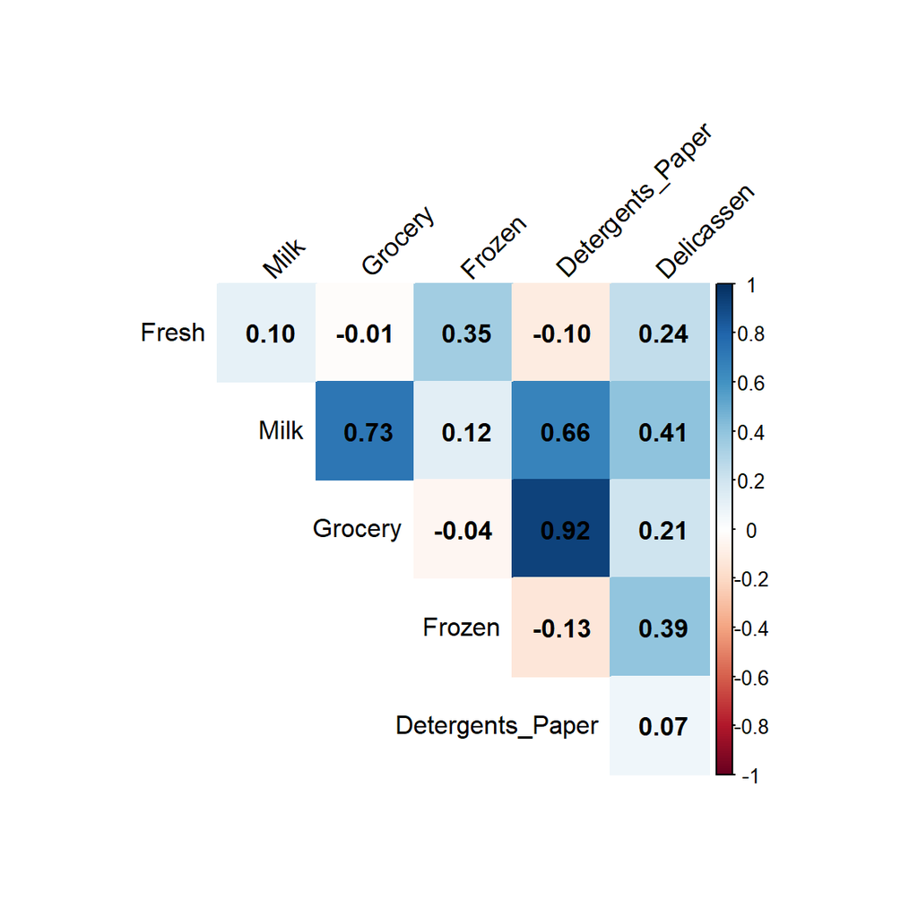

```r
cor_matrix <- cor(data_numeric)
corrplot(cor_matrix, method="color", type="upper", addCoef.col = "black",
         tl.col="black", tl.srt=45, diag=FALSE)
```

**Insights:** - There is a strong positive correlation between `Grocery` and `Detergents_Paper` ($r \approx 0.92$), and between `Milk` and `Grocery`/`Detergents_Paper`. This suggests these items are typically purchased together, likely by retail supermarkets. - `Fresh` and `Frozen` show very little correlation with the other products, indicating a different purchasing behavior.

# 5. Factor Analysis (PCA)

We execute Principal Component Analysis on the scaled, log-transformed data to uncover underlying dimensions.

```r
res.pca <- PCA(data_scaled, graph = FALSE)
```

## 5.1 Scree Plot & Variance

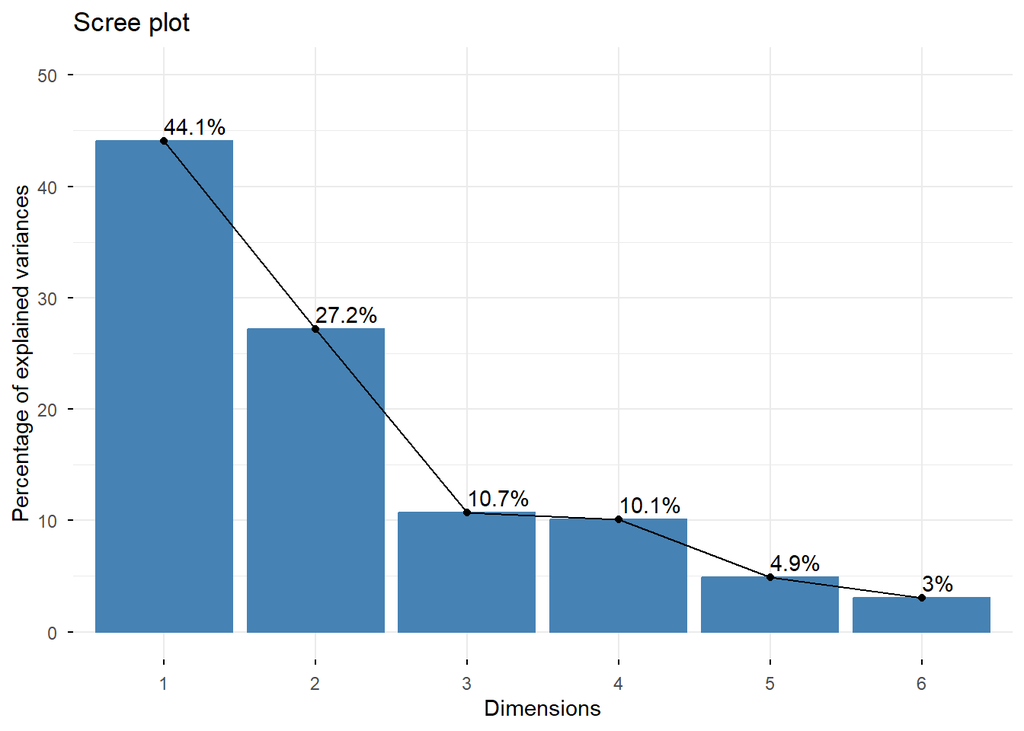

```r
fviz_eig(res.pca, addlabels = TRUE, ylim = c(0, 50))
```

**Selection of Components:** The first two principal components (Dim 1 and Dim 2) explain roughly **72% of the total variance**. We will retain these 2 components, as they capture the vast majority of the information while allowing for easy 2D visualization.

## 5.2 Variable Contributions

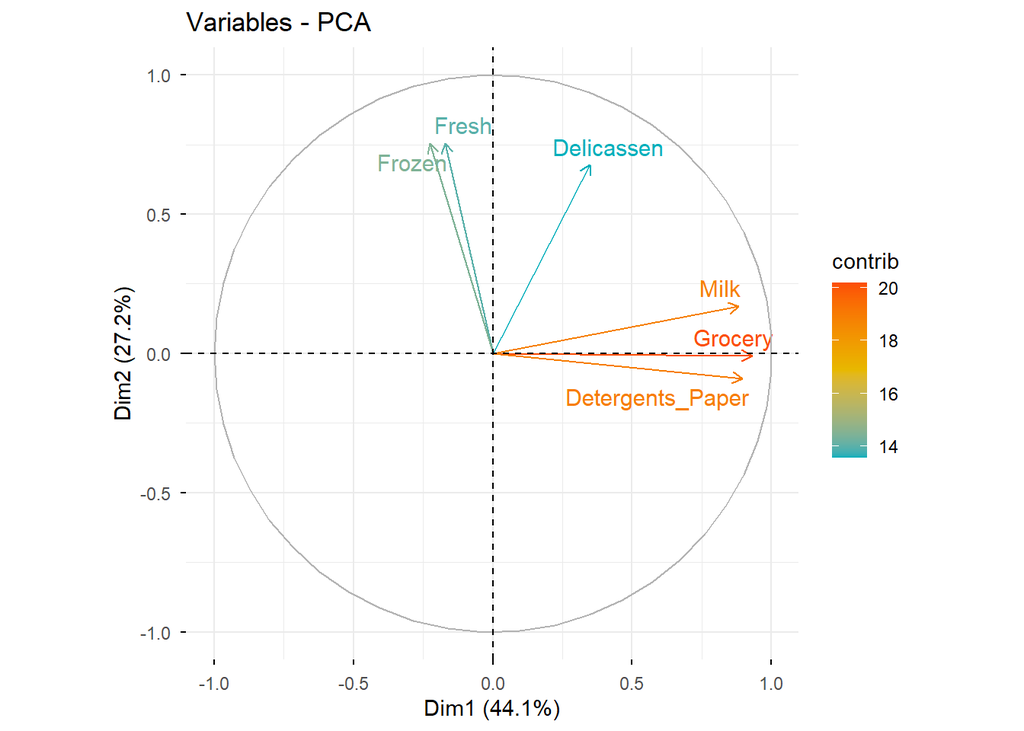

```r
fviz_pca_var(res.pca, col.var = "contrib",
             gradient.cols = c("#00AFBB", "#E7B800", "#FC4E07"),
             repel = TRUE)
```

**Interpretation of Axes:** - **Dimension 1 (Horizontal):** Highly correlated with `Detergents_Paper`, `Grocery`, and `Milk`. This axis likely represents “Retail / Supermarket Bulk Buying.” - **Dimension 2 (Vertical):** Highly correlated with `Fresh` and `Frozen`. This axis likely represents “Restaurant / Fresh Food Focus.”

## 5.3 Individual Factor Map

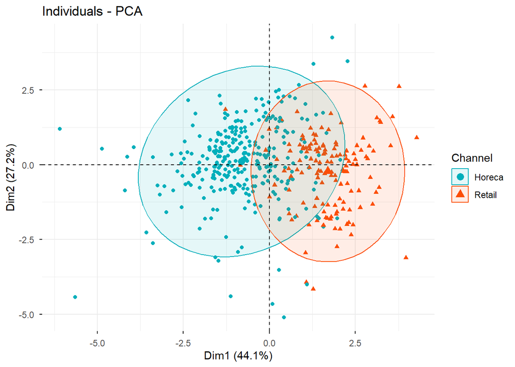

```r
fviz_pca_ind(res.pca,
             geom.ind = "point",
             col.ind = data$Channel,
             palette = c("#00AFBB", "#FC4E07"),
             addEllipses = TRUE,
             legend.title = "Channel")
```

# 6. Clustering Analysis

With the dimensionality understood, we proceed to group the customers based on their multivariate spending patterns using K-Means.

## 6.1 Optimal Number of Clusters

We use the Elbow Method to determine $k$.

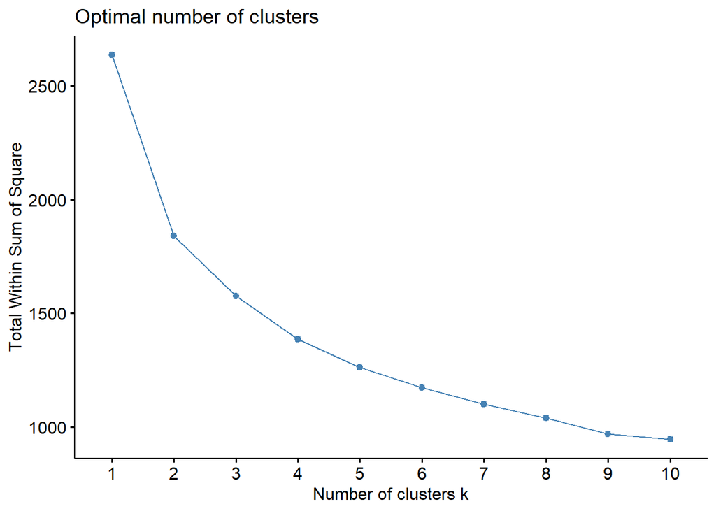

```r
set.seed(123)
fviz_nbclust(data_scaled, kmeans, method = "wss")
```

The curve bends prominently at $k = 2$ and $k = 3$. We will choose **$k = 3$** to yield more nuanced and actionable business segments.

## 6.2 Fit K-Means

```r
set.seed(123)
kmeans_res <- kmeans(data_scaled, centers = 3, nstart = 25)
data$Cluster <- as.factor(kmeans_res$cluster)
```

# 7. PCA + Cluster Integration

We project our 3 K-Means clusters onto the 2D PCA space to validate cluster quality.

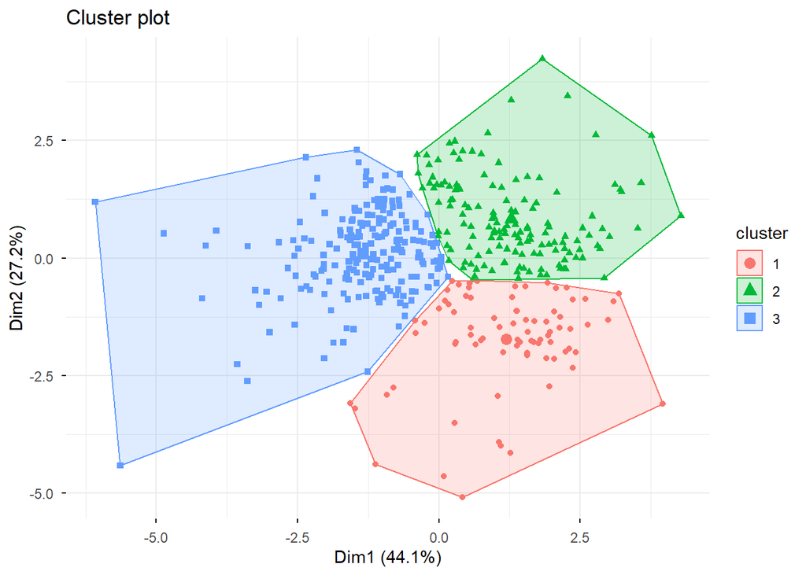

```r
fviz_cluster(kmeans_res, data = data_scaled,
             geom = "point",
             ellipse.type = "convex",
             ggtheme = theme_minimal())
```

The clusters are well-separated in the principal component space, indicating a robust clustering structure.

# 8. Business & Statistical Interpretation

To interpret the clusters, we calculate the average spending (in monetary units) across the original variables for each segment.

```r
cluster_profiles <- data %>%
  group_by(Cluster) %>%
  summarise(across(c(Fresh, Milk, Grocery, Frozen, Detergents_Paper, Delicassen), mean))

knitr::kable(cluster_profiles, digits = 0, caption = "Average Spending by Cluster")
```

Average Spending by Cluster

| Cluster | Fresh | Milk | Grocery | Frozen | Detergents_Paper | Delicassen |
| --- | --- | --- | --- | --- | --- | --- |
| 1 | 2869 | 7099 | 12459 | 607 | 5487 | 781 |
| 2 | 17043 | 10560 | 13334 | 4133 | 4987 | 2847 |
| 3 | 11993 | 1995 | 2497 | 3278 | 426 | 893 |

# 9. Conclusion

Through Multivariate Statistical Analysis (PCA) and K-Means Clustering, we successfully reduced the complexity of customer spending data and identified 3 highly distinct, actionable customer archetypes.

These profiles can now be leveraged by the marketing and sales departments to design tailored promotional strategies, ultimately maximizing revenue and customer retention.